# THSS 730 - Lab 2

Discrete distributions

Author

Byron C Jaeger

# Binomial distribution

If $X \sim \text{Binomial}(n, p)$:

- $X$ = number of successes in $n$ trials
- $n$ = number of trials
- $p$ = probability of success

## Properties of the binomial distribution

- $E(X) = np$
- $\text{Var}(X) = np(1-p)$
- $\text{SD}(X) = \sqrt{np(1-p)}$

## Problem 1

Suppose we have a sample of five phlebotomists who were exposed to Hepatitis B via a needlestick accident. Suppose that it is reasonable to assume a health worker exposed to Hepatitis B via needlestick has a 30% chance of developing the disease. Let $X$ represent how many of the five phlebotomists develop Hepatitis B.

```r
# Given parameters
n <- 5  # number of phlebotomists
p <- 0.3  # probability of developing Hepatitis B
```

1. Mean number of phlebotomists who will develop Hepatitis B

```r
mean_X <- n * p
mean_X
```

```
[1] 1.5
```

2. Standard deviation

```r
sd_X <- sqrt(n * p * (1 - p))
sd_X
```

```
[1] 1.024695
```

3. Number of ways to order the five phlebotomists (factorial of 5)

```r
num_orderings <- factorial(n)
num_orderings
```

```
[1] 120
```

4. Number of unique ways to select one phlebotomist from the group of five (combinations)

```r
num_combinations <- choose(n, 1)
num_combinations
```

```
[1] 5
```

5. Probability that exactly one phlebotomist develops the disease

```r
prob_exactly_one <- dbinom(1, size = n, prob = p)
prob_exactly_one
```

```
[1] 0.36015
```

6. Probability that none of the phlebotomists develop the disease

```r
prob_none <- dbinom(0, size = n, prob = p)
prob_none
```

```
[1] 0.16807
```

7. Probability that no more than one of the phlebotomists develop the disease

```r
prob_no_more_than_one <- pbinom(1, size = n, prob = p)
prob_no_more_than_one
```

```
[1] 0.52822
```

8. Probability that at least three of the phlebotomists develop the disease

```r
prob_at_least_three <- pbinom(2, size = n, prob = p, lower.tail = FALSE)
prob_at_least_three
```

```
[1] 0.16308
```

## Problem 2

Suppose X ~ Binomial(10, 0.2). Compute and plot the probability mass function (PMF) and the cumulative distribution function (CDF) of X.

```r
# Load functions from ggplot2
library(ggplot2)

# X ~ Binomial(10, 0.2)

n <- 10   # number of trials
p <- 0.2  # probability of success
```

Using the parameters `n` and `p`, we’ll generate values of the PMF and CDF.

```r
# Generate the range of possible outcomes for X
x_values <- 0:n

# Compute the PMF and CDF
pmf_values <- dbinom(x_values, size = n, prob = p)
cdf_values <- pbinom(x_values, size = n, prob = p)
```

Next we’ll place these vectors together with `x_values` in a `tibble`

```r
library(tibble)

# Create a data frame for plotting
data_gg <- tibble(
  x = x_values,
  pmf = pmf_values,
  cdf = cdf_values
)
```

First plot the PMF

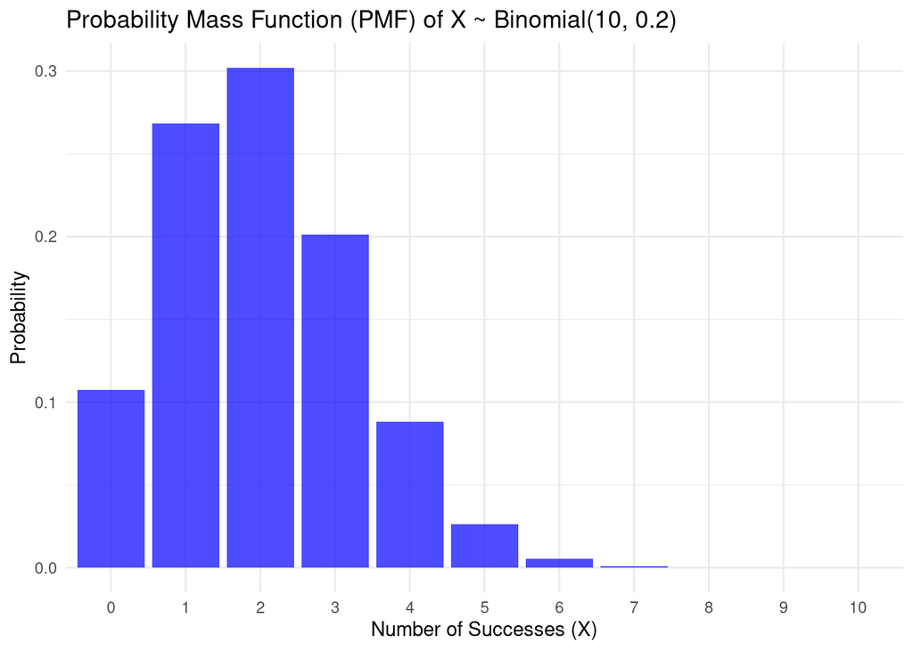

```r
ggplot(data_gg, aes(x = factor(x), y = pmf)) +
  geom_bar(stat = "identity", fill = "blue", alpha = 0.7) +
  labs(title = "Probability Mass Function (PMF) of X ~ Binomial(10, 0.2)",
       x = "Number of Successes (X)",
       y = "Probability") +
  theme_minimal()
```

Next plot the CDF

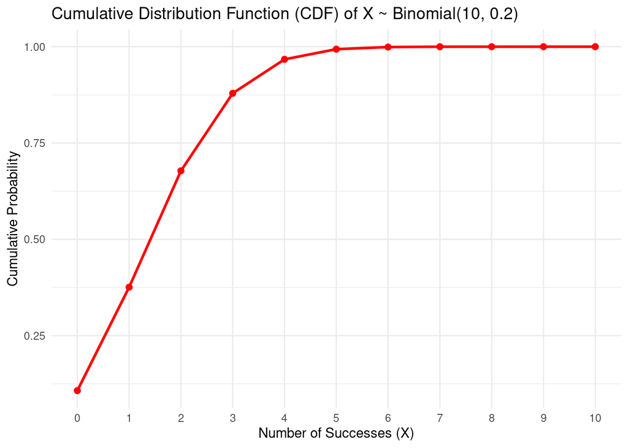

```r
ggplot(data_gg, aes(x = x, y = cdf)) +
  geom_line(color = "red", size = 1) +
  geom_point(color = "red", size = 2) +
  labs(title = "Cumulative Distribution Function (CDF) of X ~ Binomial(10, 0.2)",
       x = "Number of Successes (X)",
       y = "Cumulative Probability") +
  theme_minimal() +
  scale_x_continuous(breaks = x_values) +
  theme(panel.grid.minor.x = element_blank())
```

## Problem 3

Consider the example from lecture where a physician uses a new antihypertensive drug on the first 4 untreated hypertensive patients she encounters in her practice and X = the # of patients of 4 who are brought under control. The `“htn.xlsx”` dataset contains the results from 100 physicians who were asked to treat their next 4 untreated hypertensive patients with the drug and report their results. The data set has 2 variables:

- `physician` provides an ID from 1-100
- `num_control` gives the number out of 4 that were brought under control.

```r
library(readxl)

htn <- read_xlsx("data/htn.xlsx")

htn
```

| physician | num_control |
| --- | --- |
| 1 | 0 |
| 2 | 0 |
| 3 | 0 |
| 4 | 0 |
| 5 | 0 |
| 6 | 0 |
| 7 | 0 |
| 8 | 0 |
| 9 | 0 |
| 10 | 0 |

[output cut: 90 more lines]

We can use what we learned in Lab #1 to calculate the frequency distribution and empirical CDF and plot the frequency distribution.

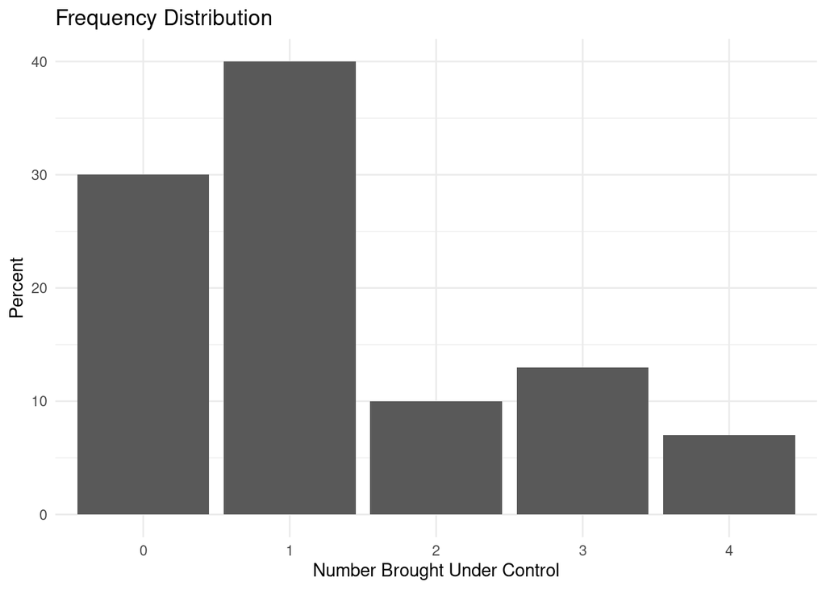

```r
library(dplyr, quietly = TRUE)

freq_dist <- htn %>%
  count(num_control) %>%
  mutate(p = n / sum(n) * 100) %>%
  rename(Percent = p)

# Plot frequency distribution
ggplot(freq_dist) +
  aes(x = as.factor(num_control), y = Percent) +
  geom_bar(stat = "identity") +
  labs(title = "Frequency Distribution",
       x = "Number Brought Under Control",
       y = "Percent") +
  theme_minimal()
```

We can also plot the empirical CDF.

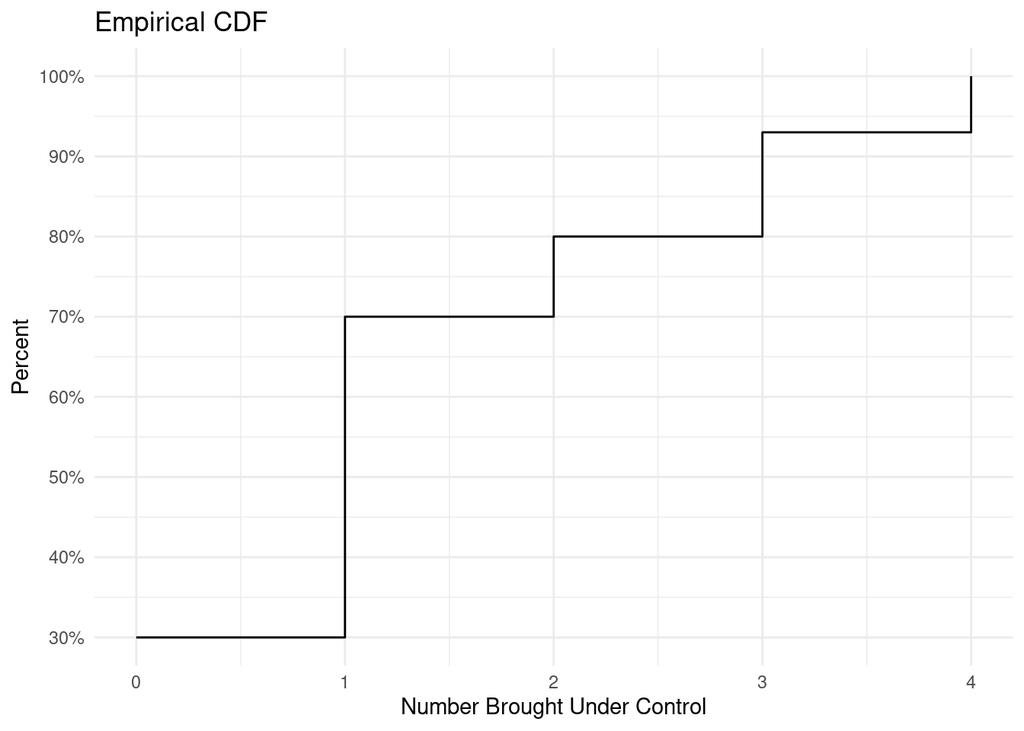

```r
# Calculate empirical CDF
ecdf_func <- ecdf(htn$num_control)

# Create a data frame for plotting
cdf_data <- data.frame(num_control = unique(htn$num_control),
                       cum_pct = ecdf_func(unique(htn$num_control)) * 100)

# Plot empirical CDF
ggplot(cdf_data, aes(x = num_control, y = cum_pct)) +
  geom_step() +
  labs(title = "Empirical CDF",
       x = "Number Brought Under Control",
       y = "Percent") +
  scale_y_continuous(breaks = seq(0, 100, by = 10),
                     labels = paste0(seq(0, 100, by = 10), '%')) +
  theme_minimal()
```

If we want to create a needle plot for the frequency distribution, we can re-use the `freq_dist` data that we created above.

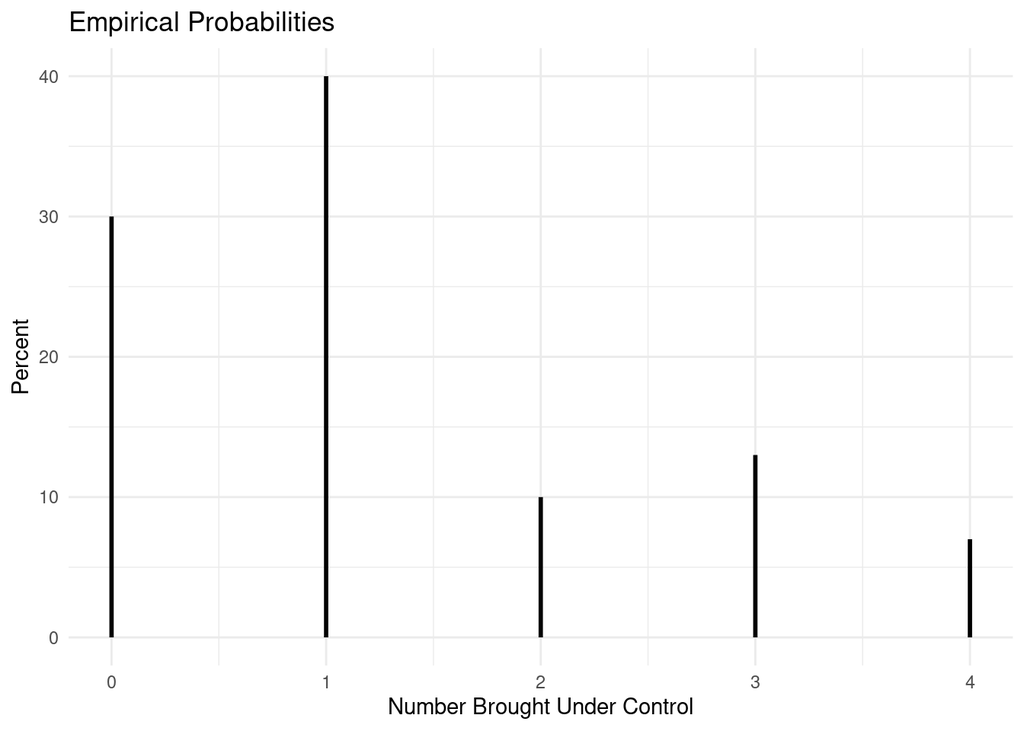

```r
# Needle plot for frequency distribution
ggplot(freq_dist, aes(x = as.numeric(num_control), y = Percent)) +
  geom_segment(aes(xend = as.numeric(num_control), yend = 0), size = 1) +
  labs(title = "Empirical Probabilities",
       x = "Number Brought Under Control",
       y = "Percent") +
  theme_minimal()
```

# Poisson Distribution

The Poisson distribution is a discrete probability distribution that expresses the probability of a given number of events occurring in a fixed interval of time or space.

If $X \sim \text{Poisson}(\mu)$, then the probability mass function is given by:

$$P(X = k) = \frac{\mu^k e^{-\mu}}{k!}$$

where:

- $k = 0, 1, 2, \dots$
- $X$ is the number of events occurring in time period $t$
- $\lambda$ is the expected number of events per unit time
- $\mu = \lambda t$ is the expected number of events in the time period $t$

## Properties of the Poisson Distribution

- $E(X) = \mu$
- $\text{Var}(X) = \mu$
- $\text{SD}(X) = \sqrt{\mu}$

## Problem 4

Vehicles pass through a junction at an average rate of 300 per hour

1. Probability that no vehicles pass in a given minute

```r
# Average rate per minute
lambda_per_minute <- 300 / 60

prob_no_vehicles <- dpois(0, lambda_per_minute)
prob_no_vehicles
```

```
[1] 0.006737947
```

2. Expected number of vehicles passing in two minutes

```r
expected_vehicles <- lambda_per_minute * 2
expected_vehicles
```

```
[1] 10
```

3. Probability that at most 5 vehicles pass in a two-minute period

```r
prob_at_most_5 <- ppois(5, lambda_per_minute * 2)
prob_at_most_5
```

```
[1] 0.06708596
```

4. Probability that more than 20 vehicles pass in two minutes

```r
prob_more_than_20 <- 1 - ppois(20, lambda_per_minute * 2)
prob_more_than_20
```

```
[1] 0.001588261
```